# Tráfico

Author

by [Santiago Mota](https://www.linkedin.com/in/santiagomota/)

Published

September 9, 2025

Keywords

R, Quarto

Creamos una variable parametrizada, `p_directorio_externo`, para que sea mas fácil pasar el material de un ordenador a otro.

```r
# https://bookdown.org/yihui/rmarkdown-cookbook/parameterized-reports.html
directorio_externo <- params$p_directorio_externo
directorio_externo
```

```
[1] "/media/enero/Disco3ATA/Varios/R/Archivos/GIS/data/"
```

```r
library(leaflet)
library(dplyr)
library(readr)
library(sf)
library(spanishoddata)
```

### 0.1 Con una url al fichero

En este caso, vamos a utilizar un código algo mas extenso para acceder a un fichero zip a partir de una url, bajarlo y descomprimirlo.

El siguiente bloque de código no se ejecuta para no saturar la web del Ayuntamiento de Madrid, pero se puede modificar fácilmente para obtener otro mes.

```r
fecha_objetivo <- data.frame(mes = '08', anio = '2025')
```

**Hacer que descargue los datos si no están en local**

```r
# Incluimos la url (este fichero corresponde a agosto 2025)
url <- paste0('https://datos.madrid.es/egobfiles/MANUAL/208627/',
              fecha_objetivo$mes[1], '-', fecha_objetivo$anio[1], '.zip')

# La url
# url

# Definimos el fichero
# fichero  <- paste0(tempfile(), ".zip")
fichero <- paste0(directorio_externo, 'ayuntamientoMadrid/trafico/historico/',
                  fecha_objetivo$mes[1], '-', fecha_objetivo$anio[1], '.zip')

# Descargamos el fichero al ordenador (comprimido ocupa 72 Mb)
download.file(url, destfile = fichero)

# Leemos el fichero con la función read.table()
# trafico_mes <- read.table(unzip(fichero, files = "06-2025.csv", exdir = tempdir()),
#                       header = TRUE, sep = ';', dec = '.')
trafico_mes <- read.table(unzip(fichero, exdir = tempdir()),
                      header = TRUE, sep = ';', dec = '.')

# Como alternativa si lo hemos bajado de internet
# trafico_mes <- read.csv2("06-2025.csv", sep=';', header=TRUE)

# El fichero
fichero

# Vemos el tamaño del fichero
print(object.size(trafico_mes), units = "Mb")
# 667.3 Mb

# Imprimimos el timestamp
fs::file_info(fichero)$modification_time
# [1] "2025-09-04 23:35:33 CEST"
```

**Aviso**

El tamaño del fichero hace que no sea muy fácil trabajar en Posit Cloud.

Vemos la memoria disponible.

```r
# Por ahora no funciona en Windows
# Ejecutamos el comando de Bash dentro de R y capturamos la salida
memoria_disponible <- as.numeric(system("free -m | awk '/^Mem:/ {print $7}'", intern = TRUE))
memoria_disponible
```

En vez de eso, usamos los datos guardados.

```r
# Incluimos la ubicación del zip
# fichero <- paste0(directorio_externo, 'ayuntamientoMadrid/trafico/historico/06-2025.zip')
# fichero <- './data/06-2025_reducido.zip'
fichero <- paste0(directorio_externo, 'ayuntamientoMadrid/trafico/historico/',
                  fecha_objetivo$mes[1], '-', fecha_objetivo$anio[1], '.zip')

# Leemos el fichero con la función read.table()
# trafico_mes <- read.table(unzip(fichero, files = "06-2025.csv", exdir = tempdir()),
#                       header = TRUE, sep = ';', dec = '.')
trafico_mes <- read.table(unzip(fichero, exdir = tempdir()),
                      header = TRUE, sep = ';', dec = '.')

# Vemos el tamaño del fichero
print(object.size(trafico_mes), units = "Mb")
```

```
667.3 Mb
```

```r
# 667.3 Mb
```

```r
# Vemos el timestamp
fs::file_info(paste0(directorio_externo, 'ayuntamientoMadrid/trafico/historico/',
                  fecha_objetivo$mes[1], '-', fecha_objetivo$anio[1], '.zip'))$modification_time
```

```
[1] "2025-09-04 23:35:33 CEST"
```

```r
# [1] "2025-09-04 23:35:33 CEST"
```

De la Estructura_DS_Contenido_Trafico_Historico.pdf sobre el contenido del fichero, resumimos los siguientes datos:

- **Nombre (Tipo)** : **Descripción**
- `id` (Entero) : Identificación única del Punto de Medida en los sistemas de control del tráfico del Ayuntamiento de Madrid.
- `fecha` (Fecha) : Fecha y hora oficiales de Madrid con formato yyyy-mm-dd hh:mi:ss.
- `identif` (Texto) : Identificador del Punto de Medida en los Sistemas de Tráfico (se proporciona por compatibilidad hacia atrás).
- `tipo_elem` (Texto) : Nombre del Tipo de Punto de Medida: Urbano o M30.
- `intensidad` (Entero): Número de vehículos en el periodo de 15 minutos, expresada en vehículos/hora. El valor efectivo de vehículos que han circulado en ese periodo se obtiene dividiendo entre cuatro. Un valor negativo implica la ausencia de datos.
- `ocupacion` (Entero) : Porcentaje de tiempo que está un detector de tráfico ocupado por un vehículo. Por ejemplo, una ocupación del 50% en un periodo de 15 minutos significa que ha habido vehículos situados sobre el detector durante 7 minutos y 30 segundos. Un valor negativo implica la ausencia de datos.
- `carga` (Entero) : Parámetro de carga del vial en el periodo de 15 minutos. Representa una estimación del grado de congestión, calculado a partir de un algoritmo que usa como variables la intensidad y ocupación, con ciertos factores de corrección. Establece el grado de uso de la vía en un rango de 0 (vacía) a 100 (colapso). Un valor negativo implica la ausencia de datos.
- `vmed` (Entero) : Velocidad media de los vehículos en el periodo de 15 minutos (Km./h). Solo para puntos de medida interurbanos M30. Un valor negativo implica la ausencia de datos.
- `error` (Texto) : Indicación de si ha habido al menos una muestra errónea o sustituida en el periodo de 15 minutos.
  - N: no ha habido errores ni sustituciones.
  - E: los parámetros de calidad de alguna de las muestras integradas no son óptimos.
  - S: alguna de las muestras recibidas era totalmente errónea y no se ha integrado.
- `periodo_integracion` (Entero): Número de muestras recibidas y consideradas para el periodo de integración.

3.1 Carga

El parámetro carga es un indicador sintético que intenta medir el grado de saturación de una vía para la toma de decisiones sobre la duración de las fases de la regulación semafórica. En la bibliografía técnica existen múltiples fórmulas para su cálculo.

Al tratarse de un valor sintético se utiliza una fórmula para su cálculo, que depende del análisis de los ingenieros de tráfico y del análisis concreto de cada uno de los cruces a los que aplica.

En la fórmula de la carga se emplean unos parámetros que se adaptan de manera empírica para atender a las características de la vía y de su entorno.

A efectos de regulación existen dos entornos en la ciudad de Madrid: - Zona urbana - M30. Con carácter general, en M30 no se calcula el parámetro carga y su valor es cero. No obstante, hay puntos de medida para los cuales sí se realiza el cálculo.

La fórmula que se utiliza es la siguiente: 𝑪 = 𝒀 + (𝟏 − 𝒀) × 𝑻𝑶 × 𝑲𝑪

siendo 𝒀= 𝑰/ 𝑰𝒔

El significado de los parámetros es el siguiente: - C: Carga del punto de medida (%) Y: Relación entre la intensidad (vehículos/hora) y la intensidad de saturación del punto de medida I: Intensidad del punto de medida (vehículos/hora) Is: Intensidad de saturación (capacidad máxima de la vía, vehículos/hora) TO: Tiempo de ocupación (tanto por 1) KC: Coeficiente de Carga. Por defecto se pone 1, pero es susceptible de modificarse después de un estudio de tráfico para adecuarlo a las características de la vía.

*Datos de carga publicados* Los valores de carga publicados son los datos brutos de carga que utilizan cada uno de los sistemas. Dado que no es un dato primario que puede variar para cada semáforo y a lo largo del tiempo con parámetros de ajuste libres para adecuarse a la realidad de cada momento, solo se publica como valor adimensional, sin justificar los coeficientes que se utilizan para su cálculo.

3.2 Tiempo de ocupación Porcentaje de tiempo que está un detector de tráfico ocupado (con un vehículo situado encima). Por ejemplo, una ocupación del 50% en un periodo de 15 minutos significa que ha habido vehículos situados sobre el detector durante 7 minutos y 30 segundos.

```r
summary(trafico_mes)
```

```
       id           fecha            tipo_elem           intensidad
 Min.   : 1006   Length:13451998    Length:13451998    Min.   :    0.0
 1st Qu.: 4692   Class :character   Class :character   1st Qu.:   40.0
 Median : 5978   Mode  :character   Mode  :character   Median :  115.0
 Mean   : 6768                                         Mean   :  249.1
 3rd Qu.:10085                                         3rd Qu.:  279.0
 Max.   :11454                                         Max.   :65334.0

   ocupacion           carga             vmed            error
 Min.   :  0.000   Min.   :  0.00   Min.   :  0.000   Length:13451998
 1st Qu.:  0.000   1st Qu.:  3.00   1st Qu.:  0.000   Class :character
 Median :  1.000   Median :  8.00   Median :  0.000   Mode  :character
 Mean   :  3.544   Mean   : 12.04   Mean   :  5.146
 3rd Qu.:  4.000   3rd Qu.: 17.00   3rd Qu.:  0.000
 Max.   :100.000   Max.   :100.00   Max.   :206.000
                                    NA's   :22283
 periodo_integracion
 Min.   : 1.00
 1st Qu.:15.00
 Median :15.00
 Mean   :16.05
 3rd Qu.:15.00
 Max.   :30.00
```

```r
#       id           fecha            tipo_elem           intensidad
# Min.   : 1006   Length:13451998    Length:13451998    Min.   :    0.0
# 1st Qu.: 4692   Class :character   Class :character   1st Qu.:   40.0
# Median : 5978   Mode  :character   Mode  :character   Median :  115.0
# Mean   : 6768                                         Mean   :  249.1
# 3rd Qu.:10085                                         3rd Qu.:  279.0
# Max.   :11454                                         Max.   :65334.0
#
#   ocupacion           carga             vmed            error
# Min.   :  0.000   Min.   :  0.00   Min.   :  0.000   Length:13451998
# 1st Qu.:  0.000   1st Qu.:  3.00   1st Qu.:  0.000   Class :character
# Median :  1.000   Median :  8.00   Median :  0.000   Mode  :character
# Mean   :  3.544   Mean   : 12.04   Mean   :  5.146
# 3rd Qu.:  4.000   3rd Qu.: 17.00   3rd Qu.:  0.000
# Max.   :100.000   Max.   :100.00   Max.   :206.000
#                                    NA's   :22283
# periodo_integracion
# Min.   : 1.00
# 1st Qu.:15.00
# Median :15.00
# Mean   :16.05
# 3rd Qu.:15.00
# Max.   :30.00
```

```r
str(trafico_mes)
```

```
'data.frame':   13451998 obs. of  9 variables:
 $ id                 : int  1006 1006 1006 1006 1006 1006 1006 1006 1006 1006 ...
 $ fecha              : chr  "2025-08-08 00:15:00" "2025-08-08 00:30:00" "2025-08-08 00:45:00" "2025-08-08 01:00:00" ...
 $ tipo_elem          : chr  "C30" "C30" "C30" "C30" ...
 $ intensidad         : int  40 0 0 0 0 0 0 0 0 0 ...
 $ ocupacion          : int  1 0 0 0 0 0 0 0 0 0 ...
 $ carga              : int  0 0 0 0 0 0 0 0 0 0 ...
 $ vmed               : num  5 0 0 0 0 0 0 0 0 0 ...
 $ error              : chr  "N" "N" "N" "N" ...
 $ periodo_integracion: int  4 5 5 5 5 5 5 5 5 5 ...
```

```r
# 'data.frame': 13451998 obs. of  9 variables:
#  $ id                 : int  1006 1006 1006 1006 1006 1006 1006 1006 1006 1006 ...
#  $ fecha              : chr  "2025-08-08 00:15:00" "2025-08-08 00:30:00" "2025-08-08 00:45:00" "2025-08-08 01:00:00" ...
#  $ tipo_elem          : chr  "C30" "C30" "C30" "C30" ...
#  $ intensidad         : int  40 0 0 0 0 0 0 0 0 0 ...
#  $ ocupacion          : int  1 0 0 0 0 0 0 0 0 0 ...
#  $ carga              : int  0 0 0 0 0 0 0 0 0 0 ...
#  $ vmed               : num  5 0 0 0 0 0 0 0 0 0 ...
#  $ error              : chr  "N" "N" "N" "N" ...
#  $ periodo_integracion: int  4 5 5 5 5 5 5 5 5 5 ...
```

```r
names(trafico_mes)
```

```
[1] "id"                  "fecha"               "tipo_elem"
[4] "intensidad"          "ocupacion"           "carga"
[7] "vmed"                "error"               "periodo_integracion"
```

```r
# [1] "id"                  "fecha"               "tipo_elem"
# [4] "intensidad"          "ocupacion"           "carga"
# [7] "vmed"                "error"               "periodo_integracion"
```

Analizamos la columna periodo de integración

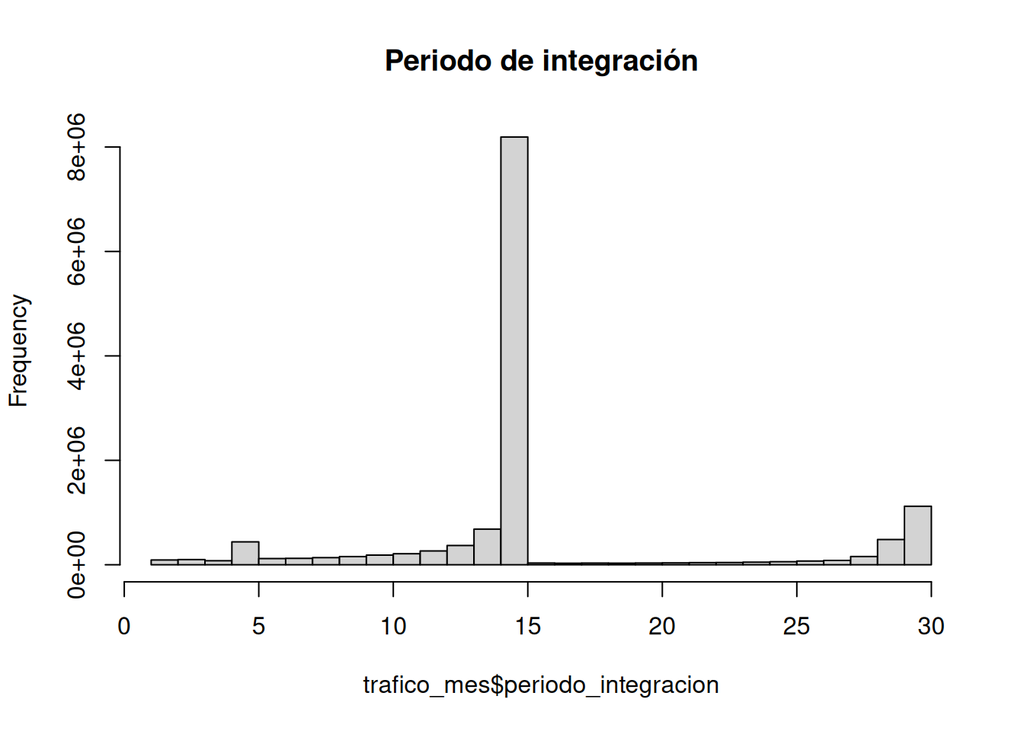

```r
hist(trafico_mes$periodo_integracion, main = 'Periodo de integración')
```

```r
table(trafico_mes$periodo_integracion, useNA = 'ifany')
```

```
      1       2       3       4       5       6       7       8       9      10
  40450   51568   99890   77605  438776  119384  122415  136848  157203  184567
     11      12      13      14      15      16      17      18      19      20
 211674  264847  368812  682579 8192131   33274   29493   32040   30820   33337
     21      22      23      24      25      26      27      28      29      30
  36386   40712   43282   49990   58267   71040   82513  157753  483650 1120692
```

La ocupación

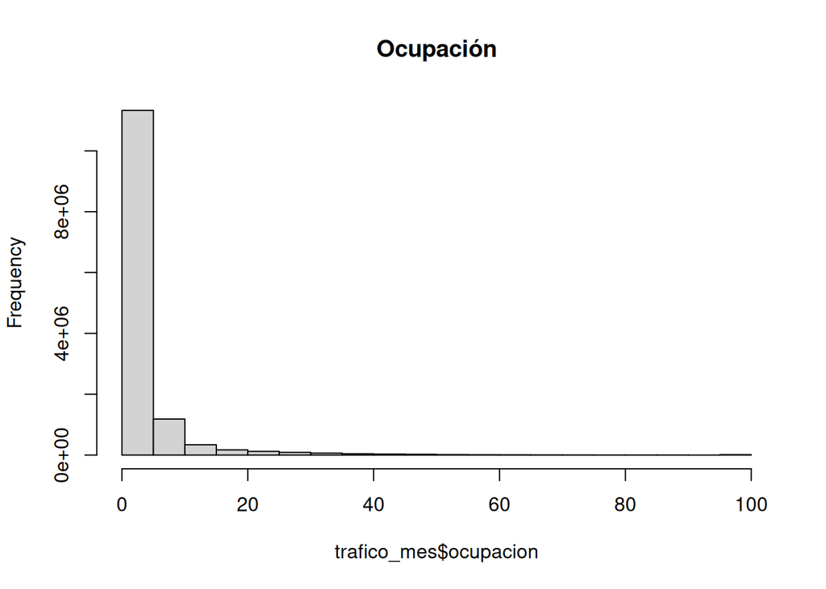

```r
hist(trafico_mes$ocupacion, main = 'Ocupación')
```

```r
table(trafico_mes$ocupacion, useNA = 'ifany')
```

```
      0       1       2       3       4       5       6       7       8       9
4198078 2740414 1767316 1228779  814106  582584  410544  295397  206841  153905
     10      11      12      13      14      15      16      17      18      19
 117510   91715   75333   65615   57480   47972   40677   35671   33753   31054
     20      21      22      23      24      25      26      27      28      29
  28107   27006   27332   22786   22414   22129   21921   20059   17454   14746
     30      31      32      33      34      35      36      37      38      39
  13926   13165   13017   15276   10977   10600    9487    9065    8402    8003
     40      41      42      43      44      45      46      47      48      49
   7704    7074    6821    6356    5789    5460    5105    4868    4581    5061
     50      51      52      53      54      55      56      57      58      59
   4974    3894    3459    3028    2896    2550    2368    2327    2067    1880
     60      61      62      63      64      65      66      67      68      69
   1748    1461    1471    1280    1203    1130    1058     925     831     811
     70      71      72      73      74      75      76      77      78      79
    658     712     539     473     429     393     330     356     261     311
     80      81      82      83      84      85      86      87      88      89
    299     250     250     226     226     240     213     228     311     150
     90      91      92      93      94      95      96      97      98      99
    183     163     165     145     128     139     188     212     359     508
    100
  12157
```

### 0.2 Tráfico en Madrid en tiempo real

Vamos a hacer un gráfico mas avanzado siguiendo con los datos del Ayuntamiento de Madrid.

Lo primero es cargar la ubicación de los puntos de medida. En la pagina del Ayuntamiento de Madrid, la ubicación de esos puntos se encuentra [aqui](https://datos.madrid.es/portal/site/egob/menuitem.c05c1f754a33a9fbe4b2e4b284f1a5a0/?vgnextoid=ee941ce6ba6d3410VgnVCM1000000b205a0aRCRD&vgnextchannel=374512b9ace9f310VgnVCM100000171f5a0aRCRD). En nuestro caso, nos hemos bajado [este](https://datos.madrid.es/egobfiles/MANUAL/202468/pmed_ubicacion_04-2024.zip). La explicación de los datos del fichero esta [aqui](https://datos.madrid.es/FWProjects/egob/Catalogo/Transporte/Trafico/ficheros/PuntosMedidaTraficoMdrid.pdf) y en esa misma página podemos encontrar un [Real decreto para la implantación de Sistemas Inteligentes de Transporte](https://datos.madrid.es/FWProjects/egob/Catalogo/Transporte/Trafico/ficheros/BOE_A_2012-5043.pdf) y la [Directiva Europea referente a los SIT](https://datos.madrid.es/FWProjects/egob/Catalogo/Transporte/Trafico/ficheros/Directiva_its_sist_transp_intelig_2010_40_UE.pdf).

```r
# directorio_zips <- list.files(paste0(directorio_externo, 'ayuntamientoMadrid/trafico/puntos_medida/'), 'shp')

library(sf)

# sf_list <- lapply(zip_files, function(zip_path) {
#   tmpdir <- tempdir()
#   unzip(zip_path, exdir = tmpdir)
#   shp_file <- list.files(tmpdir, pattern = "\\.shp$", full.names = TRUE)
#   st_read(shp_file)
# })


read_shp_from_zip <- function(zip_path = "/media/enero/Disco3ATA/Varios/R/Archivos/GIS/data/ayuntamientoMadrid/trafico/puntos_medida",
                              elemento = 1) {
  # tmpdir <- tempdir()
  tmpdir <- tempfile(pattern = paste0("unzip_", elemento))
  dir.create(tmpdir)
  unzip(zip_files[elemento], exdir = tmpdir)

  shp_files       <- list.files(tmpdir, pattern = "\\.shp$", full.names = TRUE)
  shp_files_names <- list.files(tmpdir, pattern = "\\.shp$", full.names = FALSE)

  # if (length(shp_files) == 0) {
  #   stop("No se encontró ningún archivo .shp en el zip.")
  # } else if (length(shp_files) > 1) {
  #   warning("Se encontraron múltiples archivos .shp. Se leerá solo el primero.")
  # }

  puntos_medida_temp <- st_read(shp_files[elemento], quiet = TRUE)
  puntos_medida_temp$fichero <- paste0(substr(shp_files_names[elemento], 19, 22),
                                  "-",
                                  substr(shp_files_names[elemento], 16, 17))

  return(puntos_medida_temp)
}

# Función segura para leer un shapefile desde un zip
# read_shp_from_zip <- function(zip_path, elemento = 1) {
#   # Crear subdirectorio único temporal
#   tmpdir <- tempfile(pattern = "unzip_")
#   dir.create(tmpdir)
#
#   # Descomprimir dentro del subdirectorio
#   unzip(zip_path, exdir = tmpdir)
#
#   # Buscar archivos .shp
#   shp_files       <- list.files(tmpdir, pattern = "\\.shp$", full.names = TRUE)
#   shp_files_names <- list.files(tmpdir, pattern = "\\.shp$", full.names = FALSE)
#
#   print(shp_files[elemento])
#   print("\n")
#
#   if (length(shp_files) == 0) {
#     stop(paste("No se encontró ningún archivo .shp en", zip_path))
#   } else if (length(shp_files) > 1 && elemento == 1) {
#     warning(paste("Se encontraron múltiples archivos .shp en", zip_path, "- se leerá solo el primero."))
#   }
#
#   puntos_medida <- st_read(shp_files[elemento], quiet = TRUE)
#   puntos_medida$fichero <- paste0(substr(shp_files_names[elemento], 19, 22),
#                                   "-",
#                                   substr(shp_files_names[elemento], 16, 17))
#
#   return(puntos_medida)
# }

# puntos_medida <- read_shp_from_zip("paste0(directorio_externo, 'ayuntamientoMadrid/trafico/puntos_medida')")

# Ruta a todos los .zip
# zip_files <- list.files(
#   path = paste0(directorio_externo, "ayuntamientoMadrid/trafico/puntos_medida"),
#   pattern = "\\.zip$", full.names = TRUE
# )

# Leer cada uno en una lista
# puntos_medida_list <- lapply(zip_files[36:41], read_shp_from_zip)

# Unir todos los datos en un único objeto sf
# puntos_medida <- do.call(rbind, puntos_medida_list)

# puntos_medida <- read_shp_from_zip(elemento = 1)
#
# for (i in 2:40) {
#     print(zip_files[i])
#     puntos_medida <- rbind(puntos_medida, read_shp_from_zip(elemento = i))
# }
```

```r
# Ruta a todos los .zip
# zip_files <- list.files(
#   path = paste0(directorio_externo, "trafico/puntos_medida"),
#   pattern = "\\.zip$", full.names = TRUE
# )

directorio_zips <- paste0(directorio_externo, 'ayuntamientoMadrid/trafico/puntos_medida/todos')

shp_files       <- list.files(directorio_zips,
                                pattern = "\\.shp$",
                                include.dirs = TRUE,
                                recursive = TRUE,
                                full.names = TRUE)
shp_files_names <- list.files(directorio_zips,
                                pattern = "\\.shp$",
                                include.dirs = TRUE,
                                recursive = TRUE,
                                full.names = FALSE)

# puntos_medida <- read_shp_from_zip(elemento = 1)

puntos_medida <- data.frame()

for (i in 1:length(shp_files)) {
  elemento = i
  # tmpdir <- tempdir()
  # tmpdir <- tempfile(pattern = paste0("unzip_", elemento))
  # dir.create(tmpdir)
  # print(tempdir())
  # unzip(zip_files[elemento], exdir = tmpdir)


  print(i)
  print(shp_files[elemento])

  # if (length(shp_files) == 0) {
  #   stop("No se encontró ningún archivo .shp en el zip.")
  # } else if (length(shp_files) > 1) {
  #   warning("Se encontraron múltiples archivos .shp. Se leerá solo el primero.")
  # }

  puntos_medida_temp <- st_read(shp_files[elemento], quiet = FALSE)
  puntos_medida_temp$fichero <- paste0(substr(shp_files_names[elemento], 19, 22),
                                  "-",
                                  substr(shp_files_names[elemento], 16, 17))
  # print(zip_files[i])

  names(puntos_medida_temp) <- tolower(names(puntos_medida_temp))

  puntos_medida <- rbind(puntos_medida, puntos_medida_temp)

  # file.remove(tempdir())
}
```

```
[1] 1
[1] "/media/enero/Disco3ATA/Varios/R/Archivos/GIS/data/ayuntamientoMadrid/trafico/puntos_medida/todos/pmed_ubicacion_01-2019.shp"
[1] 2
[1] "/media/enero/Disco3ATA/Varios/R/Archivos/GIS/data/ayuntamientoMadrid/trafico/puntos_medida/todos/pmed_ubicacion_01-2024.shp"
[1] 3
[1] "/media/enero/Disco3ATA/Varios/R/Archivos/GIS/data/ayuntamientoMadrid/trafico/puntos_medida/todos/pmed_ubicacion_01-2025.shp"
[1] 4
[1] "/media/enero/Disco3ATA/Varios/R/Archivos/GIS/data/ayuntamientoMadrid/trafico/puntos_medida/todos/pmed_ubicacion_02-2019.shp"
[1] 5
[1] "/media/enero/Disco3ATA/Varios/R/Archivos/GIS/data/ayuntamientoMadrid/trafico/puntos_medida/todos/pmed_ubicacion_02-2023.shp"
[1] 6
[1] "/media/enero/Disco3ATA/Varios/R/Archivos/GIS/data/ayuntamientoMadrid/trafico/puntos_medida/todos/pmed_ubicacion_02-2024.shp"
[1] 7
[1] "/media/enero/Disco3ATA/Varios/R/Archivos/GIS/data/ayuntamientoMadrid/trafico/puntos_medida/todos/pmed_ubicacion_02-2025.shp"
[1] 8
```

[output cut: 69 more lines]

```r
sort(unique(puntos_medida$fichero))
```

```
 [1] "2018-12" "2019-01" "2019-02" "2019-03" "2019-06" "2019-12" "2020-06"
 [8] "2020-09" "2020-12" "2021-06" "2021-09" "2021-12" "2022-06" "2022-09"
[15] "2022-12" "2023-02" "2023-03" "2023-04" "2023-05" "2023-06" "2023-07"
[22] "2023-08" "2023-09" "2023-10" "2023-11" "2023-12" "2024-01" "2024-02"
[29] "2024-03" "2024-04" "2024-05" "2024-06" "2024-08" "2024-09" "2024-10"
[36] "2024-11" "2024-12" "2025-01" "2025-02" "2025-03" "2025-04" "2025-05"
```

```r
#  [1] "2018-12" "2019-01" "2019-02" "2019-03" "2019-06" "2019-12" "2020-06"
#  [8] "2020-09" "2020-12" "2021-06" "2021-09" "2021-12" "2022-06" "2022-09"
# [15] "2022-12" "2023-02" "2023-03" "2023-04" "2023-05" "2023-06" "2023-07"
# [22] "2023-08" "2023-09" "2023-10" "2023-11" "2023-12" "2024-01" "2024-02"
# [29] "2024-03" "2024-04" "2024-05" "2024-06" "2024-08" "2024-09" "2024-10"
# [36] "2024-11" "2024-12" "2025-01" "2025-02" "2025-03" "2025-04" "2025-05"
```

```r
tabla_id_cod <- table(puntos_medida_ultimo$id, puntos_medida_ultimo$cod_cent)
tabla_id_cod <- as.matrix(tabla_id_cod)
```

```r
diag(tabla_id_cod) <- 0
```

```r
colSums(tabla_id_cod)
```

```r
puntos_medida$activo <- FALSE
puntos_medida$activo[puntos_medida$fichero == "2025-05"] <- TRUE
```

```r
summary(puntos_medida)
```

```
  tipo_elem            distrito           id          cod_cent
 Length:197436      Min.   : 1.00   Min.   :    0   Length:197436
 Class :character   1st Qu.: 6.00   1st Qu.: 4619   Class :character
 Mode  :character   Median :10.00   Median : 5851   Mode  :character
                    Mean   :10.07   Mean   : 6515
                    3rd Qu.:15.00   3rd Qu.: 7131
                    Max.   :21.00   Max.   :11435
                    NA's   :198
    nombre              utm_x            utm_y            longitud
 Length:197436      Min.   :429056   Min.   :4464902   Min.   :-3.837
 Class :character   1st Qu.:439508   1st Qu.:4472280   1st Qu.:-3.713
 Mode  :character   Median :441571   Median :4475817   Median :-3.689
                    Mean   :441822   Mean   :4475679   Mean   :-3.686
                    3rd Qu.:444118   3rd Qu.:4478930   3rd Qu.:-3.659
                    Max.   :453195   Max.   :4485213   Max.   :-3.552

    latitud        fichero                   geometry        activo
 Min.   :40.33   Length:197436      POLYGON      :197436   Mode :logical
 1st Qu.:40.40   Class :character   epsg:25830   :     0   FALSE:192449
 Median :40.43   Mode  :character   +proj=utm ...:     0   TRUE :4987
 Mean   :40.43
 3rd Qu.:40.46
 Max.   :40.52
```

```r
#  tipo_elem            distrito           id          cod_cent
# Length:197436      Min.   : 1.00   Min.   :    0   Length:197436
# Class :character   1st Qu.: 6.00   1st Qu.: 4619   Class :character
# Mode  :character   Median :10.00   Median : 5851   Mode  :character
#                    Mean   :10.07   Mean   : 6515
#                    3rd Qu.:15.00   3rd Qu.: 7131
#                    Max.   :21.00   Max.   :11435
#                    NA's   :198
#    nombre              utm_x            utm_y            longitud
# Length:197436      Min.   :429056   Min.   :4464902   Min.   :-3.837
# Class :character   1st Qu.:439508   1st Qu.:4472280   1st Qu.:-3.713
# Mode  :character   Median :441571   Median :4475817   Median :-3.689
#                    Mean   :441822   Mean   :4475679   Mean   :-3.686
#                    3rd Qu.:444118   3rd Qu.:4478930   3rd Qu.:-3.659
#                    Max.   :453195   Max.   :4485213   Max.   :-3.552
#
#    latitud        fichero                   geometry        activo
# Min.   :40.33   Length:197436      POLYGON      :197436   Mode :logical
# 1st Qu.:40.40   Class :character   epsg:25830   :     0   FALSE:192449
# Median :40.43   Mode  :character   +proj=utm ...:     0   TRUE :4987
# Mean   :40.43
# 3rd Qu.:40.46
# Max.   :40.52
```

```r
length(unique(puntos_medida$id))
```

```
[1] 5152
```

```r
# [1] 5152
```

```r
length(unique(puntos_medida$nombre))
```

```
[1] 8375
```

```r
# [1] 8375
```

```r
length(unique(puntos_medida$cod_cent))
```

```
[1] 5215
```

```r
# [1] 5215
```

```r
saveRDS(puntos_medida, paste0(directorio_externo,
                              'ayuntamientoMadrid/trafico/puntos_medida/puntos_medida.rds'))
```

Lo hacemos por `id` pero se podría hacer por `cod_cent`. El problema es que este último no aparece en el fichero de intensidad.

```r
# Leer el CSV con codificación adecuada
# puntos_medida <- read_csv("puntos_medida.csv", locale = locale(encoding = "ISO-8859-1"))

puntos_medida$fichero_date <- lubridate::ymd(paste0(puntos_medida$fichero, "-01"))

# Identificar las columnas excepto 'fichero'
cols_sin_fichero <- setdiff(names(puntos_medida), c("fichero", "fichero_date"))

# Agrupar y calcular mínimo y máximo de 'fichero'
agrupado <- puntos_medida %>%
  st_set_geometry(NULL) %>%  # Quitamos la geometriz
  # group_by(across(all_of(cols_sin_fichero))) %>%
  # group_by(cod_cent) %>%
  group_by(id) %>%
  summarise(
    minimo = min(fichero_date),
    maximo = max(fichero_date),
    .groups = "drop"
  )
```

```r
summary(agrupado)
```

```
       id            minimo               maximo
 Min.   :    0   Min.   :2018-12-01   Min.   :2018-12-01
 1st Qu.: 4694   1st Qu.:2018-12-01   1st Qu.:2025-05-01
 Median : 6018   Median :2018-12-01   Median :2025-05-01
 Mean   : 6815   Mean   :2019-07-21   Mean   :2025-03-22
 3rd Qu.:10100   3rd Qu.:2018-12-01   3rd Qu.:2025-05-01
 Max.   :11435   Max.   :2025-05-01   Max.   :2025-05-01
```

```r
#       id            minimo               maximo
# Min.   :    0   Min.   :2018-12-01   Min.   :2018-12-01
# 1st Qu.: 4694   1st Qu.:2018-12-01   1st Qu.:2025-05-01
# Median : 6018   Median :2018-12-01   Median :2025-05-01
# Mean   : 6815   Mean   :2019-07-21   Mean   :2025-03-22
# 3rd Qu.:10100   3rd Qu.:2018-12-01   3rd Qu.:2025-05-01
# Max.   :11435   Max.   :2025-05-01   Max.   :2025-05-01
```

```r
dim(puntos_medida)
```

```
[1] 197436     13
```

```r
puntos_medida <- left_join(puntos_medida, agrupado)
dim(puntos_medida)
```

```
[1] 197436     15
```

```r
puntos_medida_ultimo <- puntos_medida %>%
    filter(maximo == as.Date("2025-05-01", "%Y-%m-%d"))
```

```r
puntos_medida_ultimo <- puntos_medida[puntos_medida$fichero == "2025-05", ]
```

```r
summary(puntos_medida_ultimo)
```

```
  tipo_elem            distrito           id          cod_cent
 Length:4987        Min.   : 1.00   Min.   : 1001   Length:4987
 Class :character   1st Qu.: 6.00   1st Qu.: 4710   Class :character
 Mode  :character   Median :10.00   Median : 6026   Mode  :character
                    Mean   :10.33   Mean   : 6829
                    3rd Qu.:15.00   3rd Qu.:10110
                    Max.   :21.00   Max.   :11435
                    NA's   :5
    nombre              utm_x            utm_y            longitud
 Length:4987        Min.   :429061   Min.   :4464902   Min.   :-3.837
 Class :character   1st Qu.:439545   1st Qu.:4472330   1st Qu.:-3.713
 Mode  :character   Median :441760   Median :4475893   Median :-3.687
                    Mean   :441985   Mean   :4475781   Mean   :-3.684
                    3rd Qu.:444362   3rd Qu.:4479047   3rd Qu.:-3.656
                    Max.   :453195   Max.   :4485213   Max.   :-3.552

    latitud        fichero           activo         fichero_date
 Min.   :40.33   Length:4987        Mode:logical   Min.   :2025-05-01
 1st Qu.:40.40   Class :character   TRUE:4987      1st Qu.:2025-05-01
 Median :40.43   Mode  :character                  Median :2025-05-01
 Mean   :40.43                                     Mean   :2025-05-01
 3rd Qu.:40.46                                     3rd Qu.:2025-05-01
 Max.   :40.52                                     Max.   :2025-05-01

     minimo               maximo                    geometry
 Min.   :2018-12-01   Min.   :2025-05-01   POLYGON      :4987
 1st Qu.:2018-12-01   1st Qu.:2025-05-01   epsg:25830   :   0
 Median :2018-12-01   Median :2025-05-01   +proj=utm ...:   0
 Mean   :2019-07-24   Mean   :2025-05-01
 3rd Qu.:2018-12-01   3rd Qu.:2025-05-01
 Max.   :2025-05-01   Max.   :2025-05-01
```

```r
#  tipo_elem            distrito           id          cod_cent
# Length:4987        Min.   : 1.00   Min.   : 1001   Length:4987
# Class :character   1st Qu.: 6.00   1st Qu.: 4710   Class :character
# Mode  :character   Median :10.00   Median : 6026   Mode  :character
#                    Mean   :10.33   Mean   : 6829
#                    3rd Qu.:15.00   3rd Qu.:10110
#                    Max.   :21.00   Max.   :11435
#                    NA's   :5
#    nombre              utm_x            utm_y            longitud
# Length:4987        Min.   :429061   Min.   :4464902   Min.   :-3.837
# Class :character   1st Qu.:439545   1st Qu.:4472330   1st Qu.:-3.713
# Mode  :character   Median :441760   Median :4475893   Median :-3.687
#                    Mean   :441985   Mean   :4475781   Mean   :-3.684
#                    3rd Qu.:444362   3rd Qu.:4479047   3rd Qu.:-3.656
#                    Max.   :453195   Max.   :4485213   Max.   :-3.552
#
#    latitud        fichero           activo         fichero_date
# Min.   :40.33   Length:4987        Mode:logical   Min.   :2025-05-01
# 1st Qu.:40.40   Class :character   TRUE:4987      1st Qu.:2025-05-01
# Median :40.43   Mode  :character                  Median :2025-05-01
# Mean   :40.43                                     Mean   :2025-05-01
# 3rd Qu.:40.46                                     3rd Qu.:2025-05-01
# Max.   :40.52                                     Max.   :2025-05-01
#
#     minimo               maximo                    geometry
# Min.   :2018-12-01   Min.   :2025-05-01   POLYGON      :4987
# 1st Qu.:2018-12-01   1st Qu.:2025-05-01   epsg:25830   :   0
# Median :2018-12-01   Median :2025-05-01   +proj=utm ...:   0
# Mean   :2019-07-24   Mean   :2025-05-01
# 3rd Qu.:2018-12-01   3rd Qu.:2025-05-01
# Max.   :2025-05-01   Max.   :2025-05-01
```

```r
id_activos    <- unique(puntos_medida_ultimo$id)
id_no_activos <- puntos_medida$id[!(puntos_medida$id %in% id_activos)]
puntos_medida_no_activo <- puntos_medida[!(puntos_medida$id %in% id_activos), ]
```

```r
summary(puntos_medida_no_activo)
```

```
  tipo_elem            distrito          id          cod_cent
 Length:2310        Min.   : 1.0   Min.   :    0   Length:2310
 Class :character   1st Qu.: 5.0   1st Qu.: 4485   Class :character
 Mode  :character   Median : 9.0   Median : 5992   Mode  :character
                    Mean   : 9.5   Mean   : 6424
                    3rd Qu.:15.0   3rd Qu.: 7081
                    Max.   :21.0   Max.   :11349
    nombre              utm_x            utm_y            longitud
 Length:2310        Min.   :434028   Min.   :4468585   Min.   :-3.778
 Class :character   1st Qu.:439856   1st Qu.:4471517   1st Qu.:-3.709
 Mode  :character   Median :441926   Median :4474559   Median :-3.685
                    Mean   :442022   Mean   :4475128   Mean   :-3.683
                    3rd Qu.:444695   3rd Qu.:4478882   3rd Qu.:-3.652
                    Max.   :451183   Max.   :4483510   Max.   :-3.575
    latitud        fichero            activo         fichero_date
 Min.   :40.37   Length:2310        Mode :logical   Min.   :2018-12-01
 1st Qu.:40.39   Class :character   FALSE:2310      1st Qu.:2019-06-01
 Median :40.42   Mode  :character                   Median :2021-06-01
 Mean   :40.42                                      Mean   :2021-07-15
 3rd Qu.:40.46                                      3rd Qu.:2023-07-01
 Max.   :40.50                                      Max.   :2025-04-01
     minimo               maximo                    geometry
 Min.   :2018-12-01   Min.   :2018-12-01   POLYGON      :2310
 1st Qu.:2018-12-01   1st Qu.:2021-09-01   epsg:25830   :   0
 Median :2018-12-01   Median :2024-04-01   +proj=utm ...:   0
 Mean   :2019-02-10   Mean   :2023-04-24
 3rd Qu.:2018-12-01   3rd Qu.:2024-12-24
 Max.   :2024-10-01   Max.   :2025-04-01
```

```r
#  tipo_elem            distrito          id          cod_cent
# Length:2310        Min.   : 1.0   Min.   :    0   Length:2310
# Class :character   1st Qu.: 5.0   1st Qu.: 4485   Class :character
# Mode  :character   Median : 9.0   Median : 5992   Mode  :character
#                    Mean   : 9.5   Mean   : 6424
#                    3rd Qu.:15.0   3rd Qu.: 7081
#                    Max.   :21.0   Max.   :11349
#    nombre              utm_x            utm_y            longitud
# Length:2310        Min.   :434028   Min.   :4468585   Min.   :-3.778
# Class :character   1st Qu.:439856   1st Qu.:4471517   1st Qu.:-3.709
# Mode  :character   Median :441926   Median :4474559   Median :-3.685
#                    Mean   :442022   Mean   :4475128   Mean   :-3.683
#                    3rd Qu.:444695   3rd Qu.:4478882   3rd Qu.:-3.652
#                    Max.   :451183   Max.   :4483510   Max.   :-3.575
#    latitud        fichero            activo         fichero_date
# Min.   :40.37   Length:2310        Mode :logical   Min.   :2018-12-01
# 1st Qu.:40.39   Class :character   FALSE:2310      1st Qu.:2019-06-01
# Median :40.42   Mode  :character                   Median :2021-06-01
# Mean   :40.42                                      Mean   :2021-07-15
# 3rd Qu.:40.46                                      3rd Qu.:2023-07-01
# Max.   :40.50                                      Max.   :2025-04-01
#     minimo               maximo                    geometry
# Min.   :2018-12-01   Min.   :2018-12-01   POLYGON      :2310
# 1st Qu.:2018-12-01   1st Qu.:2021-09-01   epsg:25830   :   0
# Median :2018-12-01   Median :2024-04-01   +proj=utm ...:   0
# Mean   :2019-02-10   Mean   :2023-04-24
# 3rd Qu.:2018-12-01   3rd Qu.:2024-12-24
# Max.   :2024-10-01   Max.   :2025-04-01
```

```r
puntos_medida <- rbind(puntos_medida_ultimo, puntos_medida_no_activo)
```

```r
puntos_medida$fichero   <- as.factor(puntos_medida$fichero)
puntos_medida$tipo_elem <- as.factor(puntos_medida$tipo_elem)
puntos_medida$distrito  <- as.factor(puntos_medida$distrito)
puntos_medida$cod_cent  <- as.factor(puntos_medida$cod_cent)
```

```r
summary(puntos_medida)
```

```
 tipo_elem       distrito          id              cod_cent
 M30  : 630   8      : 720   Min.   :    0   90EL00PM01:  41
 other: 174   5      : 629   1st Qu.: 4668   31018     :  40
 URB  :6493   15     : 624   Median : 6002   11025     :  39
              10     : 524   Mean   : 6701   14042     :  38
              2      : 441   3rd Qu.: 9980   82403     :  38
              (Other):4354   Max.   :11435   82404     :  38
              NA's   :   5                   (Other)   :7063
    nombre              utm_x            utm_y            longitud
 Length:7297        Min.   :429061   Min.   :4464902   Min.   :-3.837
 Class :character   1st Qu.:439596   1st Qu.:4472113   1st Qu.:-3.712
 Mode  :character   Median :441782   Median :4475295   Median :-3.687
                    Mean   :441997   Mean   :4475574   Mean   :-3.684
                    3rd Qu.:444561   3rd Qu.:4478986   3rd Qu.:-3.654
                    Max.   :453195   Max.   :4485213   Max.   :-3.552

    latitud         fichero       activo         fichero_date
 Min.   :40.33   2025-05:4987   Mode :logical   Min.   :2018-12-01
 1st Qu.:40.40   2019-02: 141   FALSE:2310      1st Qu.:2023-09-01
 Median :40.43   2019-03: 139   TRUE :4987      Median :2025-05-01
 Mean   :40.43   2018-12: 138                   Mean   :2024-02-17
 3rd Qu.:40.46   2019-06: 136                   3rd Qu.:2025-05-01
 Max.   :40.52   2019-01: 135                   Max.   :2025-05-01
                 (Other):1621
     minimo               maximo                    geometry
 Min.   :2018-12-01   Min.   :2018-12-01   POLYGON      :7297
 1st Qu.:2018-12-01   1st Qu.:2025-01-01   epsg:25830   :   0
 Median :2018-12-01   Median :2025-05-01   +proj=utm ...:   0
 Mean   :2019-06-02   Mean   :2024-09-09
 3rd Qu.:2018-12-01   3rd Qu.:2025-05-01
 Max.   :2025-05-01   Max.   :2025-05-01
```

```r
# tipo_elem       distrito          id              cod_cent       nombre
# M30  : 630   8      : 720   Min.   :    0   90EL00PM01:  41   Length:7297
# other: 174   5      : 629   1st Qu.: 4668   31018     :  40   Class :character
# URB  :6493   15     : 624   Median : 6002   11025     :  39   Mode  :character
#              10     : 524   Mean   : 6701   14042     :  38
#              2      : 441   3rd Qu.: 9980   82403     :  38
#              (Other):4354   Max.   :11435   82404     :  38
#              NA's   :   5                   (Other)   :7063
#     utm_x            utm_y            longitud         latitud
# Min.   :429061   Min.   :4464902   Min.   :-3.837   Min.   :40.33
# 1st Qu.:439596   1st Qu.:4472113   1st Qu.:-3.712   1st Qu.:40.40
# Median :441782   Median :4475295   Median :-3.687   Median :40.43
# Mean   :441997   Mean   :4475574   Mean   :-3.684   Mean   :40.43
# 3rd Qu.:444561   3rd Qu.:4478986   3rd Qu.:-3.654   3rd Qu.:40.46
# Max.   :453195   Max.   :4485213   Max.   :-3.552   Max.   :40.52
#
#    fichero       activo         fichero_date            minimo
# 2025-05:4987   Mode :logical   Min.   :2018-12-01   Min.   :2018-12-01
# 2019-02: 141   FALSE:2310      1st Qu.:2023-09-01   1st Qu.:2018-12-01
# 2019-03: 139   TRUE :4987      Median :2025-05-01   Median :2018-12-01
# 2018-12: 138                   Mean   :2024-02-17   Mean   :2019-06-02
# 2019-06: 136                   3rd Qu.:2025-05-01   3rd Qu.:2018-12-01
# 2019-01: 135                   Max.   :2025-05-01   Max.   :2025-05-01
# (Other):1621
#     maximo                    geometry
# Min.   :2018-12-01   POLYGON      :7297
# 1st Qu.:2025-01-01   epsg:25830   :   0
# Median :2025-05-01   +proj=utm ...:   0
# Mean   :2024-09-09
# 3rd Qu.:2025-05-01
# Max.   :2025-05-01
```

```r
# Unir con el dataframe original
puntos_medida_completo <- puntos_medida %>%
  st_join(agrupado, by = cols_sin_fichero)

# Eliminar la columna 'fichero'
puntos_medida_final <- puntos_medida_completo %>%
  select(-fichero) %>%
  distinct()

# Guardar si lo deseas
# write_csv(puntos_medida_final, "puntos_medida_limpio.csv")

# Ver primeras filas
print(head(puntos_medida_final))
```

```r
saveRDS(puntos_medida, paste0(directorio_externo,
                              'ayuntamientoMadrid/trafico/puntos_medida/puntos_medida.rds'))
```

```r
puntos_medida <- readRDS(paste0(directorio_externo,
                                'ayuntamientoMadrid/trafico/puntos_medida/puntos_medida.rds'))
```

```r
puntos_por_igualdad <- puntos_medida %>%
  select(-fichero, -fichero_date) %>%
  st_equals(puntos_medida) %>%
  # lengths() %>%
  duplicated()

sum(puntos_por_igualdad)
```

```r
# Total distintos:
n_distintos <- nrow(puntos_medida) - puntos_por_igualdad
print(n_distintos)
```

```r
puntos_distintos_completos <- puntos_medida %>%
  select(-fichero, -fichero_date) %>%
  distinct()

summary(puntos_distintos_completos)
```

```
 tipo_elem       distrito          id           cod_cent       nombre
 M30  : 341   8      : 550   Min.   :    0   11025  :   5   Length:5320
 other: 130   15     : 469   1st Qu.: 4692   14042  :   5   Class :character
 URB  :4849   16     : 392   Median : 6016   46406  :   5   Mode  :character
              5      : 382   Mean   : 6808   46409  :   5
              11     : 379   3rd Qu.:10081   02008  :   4
              (Other):3143   Max.   :11435   15303  :   4
              NA's   :   5                   (Other):5292
     utm_x            utm_y            longitud         latitud
 Min.   :429061   Min.   :4464902   Min.   :-3.837   Min.   :40.33
 1st Qu.:439559   1st Qu.:4472312   1st Qu.:-3.713   1st Qu.:40.40
 Median :441752   Median :4475760   Median :-3.687   Median :40.43
 Mean   :441997   Mean   :4475727   Mean   :-3.684   Mean   :40.43
 3rd Qu.:444408   3rd Qu.:4478998   3rd Qu.:-3.656   3rd Qu.:40.46
 Max.   :453195   Max.   :4485213   Max.   :-3.552   Max.   :40.52

   activo            minimo               maximo                    geometry
 Mode :logical   Min.   :2018-12-01   Min.   :2018-12-01   POLYGON      :5320
 FALSE:333       1st Qu.:2018-12-01   1st Qu.:2025-05-01   epsg:25830   :   0
 TRUE :4987      Median :2018-12-01   Median :2025-05-01   +proj=utm ...:   0
                 Mean   :2019-07-18   Mean   :2025-03-01
                 3rd Qu.:2018-12-01   3rd Qu.:2025-05-01
                 Max.   :2025-05-01   Max.   :2025-05-01
```

```r
# tipo_elem       distrito          id           cod_cent       nombre
# M30  : 341   8      : 550   Min.   :    0   11025  :   5   Length:5320
# other: 130   15     : 469   1st Qu.: 4692   14042  :   5   Class :character
# URB  :4849   16     : 392   Median : 6016   46406  :   5   Mode  :character
#              5      : 382   Mean   : 6808   46409  :   5
#              11     : 379   3rd Qu.:10081   02008  :   4
#              (Other):3143   Max.   :11435   15303  :   4
#              NA's   :   5                   (Other):5292
#     utm_x            utm_y            longitud         latitud
# Min.   :429061   Min.   :4464902   Min.   :-3.837   Min.   :40.33
# 1st Qu.:439559   1st Qu.:4472312   1st Qu.:-3.713   1st Qu.:40.40
# Median :441752   Median :4475760   Median :-3.687   Median :40.43
# Mean   :441997   Mean   :4475727   Mean   :-3.684   Mean   :40.43
# 3rd Qu.:444408   3rd Qu.:4478998   3rd Qu.:-3.656   3rd Qu.:40.46
# Max.   :453195   Max.   :4485213   Max.   :-3.552   Max.   :40.52
#
#   activo            minimo               maximo                    geometry
# Mode :logical   Min.   :2018-12-01   Min.   :2018-12-01   POLYGON      :5320
# FALSE:333       1st Qu.:2018-12-01   1st Qu.:2025-05-01   epsg:25830   :   0
# TRUE :4987      Median :2018-12-01   Median :2025-05-01   +proj=utm ...:   0
#                 Mean   :2019-07-18   Mean   :2025-03-01
#                 3rd Qu.:2018-12-01   3rd Qu.:2025-05-01
#                 Max.   :2025-05-01   Max.   :2025-05-01
```

Si atendemos a la separación espacial.

```r
puntos_puntos_distintos <- puntos_medida %>%
  select(-fichero, -fichero_date) %>%
  st_geometry() %>%
  unique()


print(length(puntos_puntos_distintos))
```

```
[1] 5170
```

```r
# [1] 5170
```

```r
fichero_puntos <- list.files(paste0(directorio_externo,
                                    'ayuntamientoMadrid/trafico/puntos_medida/ultimo'), 'shp')
```

```r
# ETRS89 / UTM zone 30N / EPSG:25830
# La base de datos de sistemas de referencia: http://spatialreference.org/ref/

# La librería maptools
# library(maptools)

# datos de proyecciones
# usados en datos cartográficos
# ED50       <- CRS(paste("+proj=utm +zone=30 +ellps=intl +units=m +no_defs"))
# WGS84      <- CRS("+proj=longlat +ellps=WGS84 +datum=WGS84 +no_defs")
# EPSG_25830 <- CRS("+init=epsg:25830")

# Los leemos con sf
# https://datos.madrid.es/egobfiles/MANUAL/202468/pmed_ubicacion_06-2025.zip
# puntos_medida <- sf::st_read("./data/pmed_ubicacion_06-2025/pmed_ubicacion_06-2025.shp")
# fichero2 <- paste0(directorio_externo, 'ayuntamientoMadrid/trafico/puntos_medida/pmed_ubicacion_06-2025.zip')

# puntos_medida <- sf::st_read(unzip(fichero2, exdir = tempdir()))
# puntos_medida <- sf::st_read(paste0(directorio_externo, 'ayuntamientoMadrid/trafico/puntos_medida/pmed_ubicacion_06-2025/pmed_ubicacion_04-2025.shp'))
puntos_medida_ultimo <- sf::st_read(paste0(directorio_externo, 'ayuntamientoMadrid/trafico/puntos_medida/ultimo/', fichero_puntos))
# Reading layer `pmed_ubicacion_04-2025' from data source `/media/enero/Disco3ATA/Varios/R/Archivos/GIS/data/ayuntamientoMadrid/trafico/puntos_medida/ultimo/pmed_ubicacion_04-2025.shp' using driver `ESRI Shapefile'
# Simple feature collection with 5001 features and 9 fields
# Geometry type: POLYGON
# Dimension:     XY
# Bounding box:  xmin: 429051.7 ymin: 4464892 xmax: 453204.2 ymax: 4485222
# Projected CRS: ETRS89 / UTM zone 30N
```

Un gráfico con la función base de R, `plot()`.

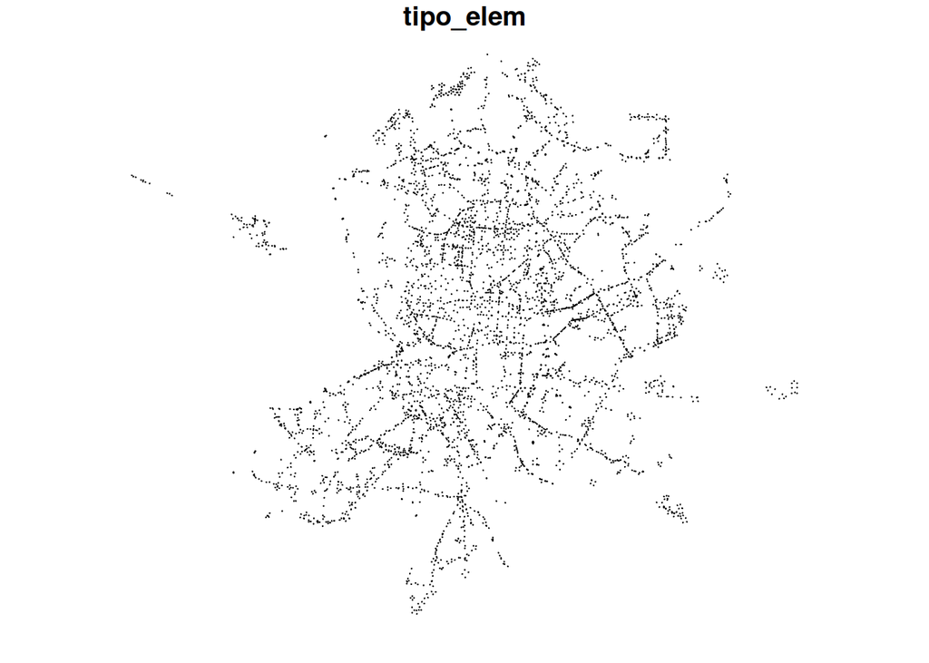

```r
plot(puntos_medida_ultimo,  max.plot = 1)
```

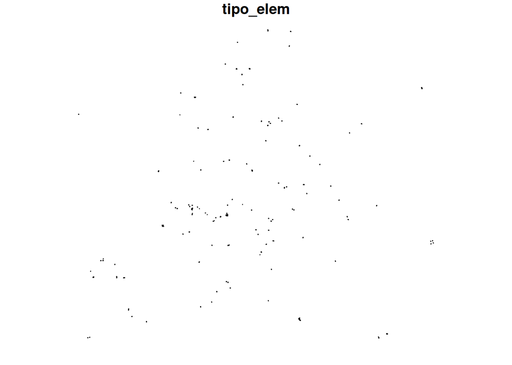

```r
plot(puntos_medida_no_activo,  max.plot = 1)
```

Comprobamos el sistema de coordenadas de los puntos de medida.

```r
sf::st_crs(puntos_medida_ultimo)$input
```

```
[1] "ETRS89 / UTM zone 30N"
```

```r
# [1] "ETRS89 / UTM zone 30N"
```

Y lo transformamos en el CRS `EPSG:4326` que es el que usa `leaflet`.

```r
puntos_medida_ultimo <- sf::st_transform(puntos_medida_ultimo, 4326)
```

Comprobamos ahora el CRS.

```r
sf::st_crs(puntos_medida_ultimo)$input
```

```
[1] "EPSG:4326"
```

```r
# [1] "EPSG:4326"
```

Y ponemos los nombres en minúsculas.

```r
names(puntos_medida_ultimo) <- tolower(names(puntos_medida_ultimo))
```

Obtenemos ahora los [datos de tráfico en tiempo real del Ayuntamiento de Madrid](http://datos.madrid.es/portal/site/egob/menuitem.c05c1f754a33a9fbe4b2e4b284f1a5a0/?vgnextoid=02f2c23866b93410VgnVCM1000000b205a0aRCRD&vgnextchannel=374512b9ace9f310VgnVCM100000171f5a0aRCRD&vgnextfmt=default) en formato `XML`.

Tenemos dos puntos de acceso: https://datos.madrid.es/egob/catalogo/202087-0-trafico-intensidad.xml y https://informo.madrid.es/informo/tmadrid/pm.xml

```r
# https://stackoverflow.com/questions/32019566/r-xml-parse-for-a-web-address
library(httr)
library(XML)

# La url
# intensidad_url <- "https://datos.madrid.es/egob/catalogo/202087-0-trafico-intensidad.xml"
intensidad_url <- "https://informo.madrid.es/informo/tmadrid/pm.xml"

# El User Agent. Hace falta desde hace poco, si no se usa no lee los datos
UA     <- "Mozilla/5.0 (Windows NT 6.1; WOW64) AppleWebKit/537.36 (KHTML, like Gecko) Chrome/41.0.2227.0 Safari/537.36"
my_url <- intensidad_url

# Si aparece un error, nos quedamos con el valor guardado
tryCatch( {
    intensidad_doc <- GET(my_url, user_agent(UA), encoding = "UTF-8")
}, error = function(e) {
    print(paste("Hay un error al acceder a: ", my_url, "\n"))
    cli::cli_alert(
        "El mensaje de error es: {e$message}"
    )
    # Nos quedamos con el valor de 2024-11-21
    intensidad_doc <- readRDS('./data/intensidad_doc_2025-05-07.rds')
    }
)

# Otras dos formas con las que podríamos "parsear" los datos
# intensidad_doc  <- XML::xmlParse(content(intensidad_doc, "text"))
# intensidad_doc <- xml2::read_xml(content(intensidad_doc, "text"))

# El documento XML asignamos a intensidad_doc
intensidad_doc <- xmlTreeParse(intensidad_doc, useInternal = TRUE,
                               encoding = "UTF-8")
```

```
No encoding supplied: defaulting to UTF-8.
```

```r
# Vemos la clase
class(intensidad_doc)
```

```
[1] "XMLInternalDocument" "XMLAbstractDocument"
```

En el código anterior hemos usado la función `tryCatch()` para evitar que el código se pare si aparece un error. En este caso, lo que hace la función es asignar al objeto `intensidad_doc` el valor almacenado en el directorio `./data`.

Lo pasamos a una lista con la función `xmlToList()`.

```r
intensidad_list <- xmlToList(intensidad_doc)

# Vemos la clase del objeto
class(intensidad_list)
```

```
[1] "list"
```

```r
# [1] "list"
```

Vemos la hora de los datos:

```r
intensidad_list$fecha_hora
```

```
[1] "09/09/2025 9:30:05"
```

Creamos un data frame `intensidad` vacío de la dimensión adecuada.

```r
intensidad <- data.frame(idelem         = rep("", length(intensidad_list)),
                         descripcion    = rep("", length(intensidad_list)),
                         accesoAsociado = rep("", length(intensidad_list)),
                         intensidad     = rep("", length(intensidad_list)),
                         ocupacion      = rep("", length(intensidad_list)),
                         carga          = rep("", length(intensidad_list)),
                         nivelServicio  = rep("", length(intensidad_list)),
                         intensidadSat  = rep("", length(intensidad_list)),
                         error          = rep("", length(intensidad_list)),
                         subarea        = rep("", length(intensidad_list)),
                         st_x           = rep("", length(intensidad_list)),
                         st_y           = rep("", length(intensidad_list)),
                         stringsAsFactors = FALSE)
```

En los datos hay valores con errores, así que definimos una función para comprobarlos antes.

```r
chequeaDatos <- function(variable) {
      if (length(variable) > 0) {as.character(variable)} else {""}
}
```

Esta función lo único que hace es comprobar si la longitud de la variable es `>0` la pasa a `caracter` y sino le adjudica el valor `""` (carácter vacío).

Analizamos en un bucle todas la variables.

```r
for (i in 1:length(intensidad_list)){
      intensidad$idelem[i]         <- chequeaDatos(intensidad_list[i]$pm$idelem)
      intensidad$descripcion[i]    <- chequeaDatos(intensidad_list[i]$pm$descripcion)
      intensidad$accesoAsociado[i] <- chequeaDatos(intensidad_list[i]$pm$accesoAsociado)
      intensidad$intensidad[i]     <- chequeaDatos(intensidad_list[i]$pm$intensidad)
      intensidad$ocupacion[i]      <- chequeaDatos(intensidad_list[i]$pm$ocupacion)
      intensidad$carga[i]          <- chequeaDatos(intensidad_list[i]$pm$carga)
      intensidad$nivelServicio[i]  <- chequeaDatos(intensidad_list[i]$pm$nivelServicio)
      intensidad$intensidadSat[i]  <- chequeaDatos(intensidad_list[i]$pm$intensidadSat)
      intensidad$error[i]          <- chequeaDatos(intensidad_list[i]$pm$error)
      intensidad$subarea[i]        <- chequeaDatos(intensidad_list[i]$pm$subarea)
      intensidad$st_x[i]           <- chequeaDatos(intensidad_list[i]$pm$st_x)
      intensidad$st_y[i]           <- chequeaDatos(intensidad_list[i]$pm$st_y)
}
```

Un poco de ETL.

Cambiamos de formato algunas variables.

```r
# Seleccionamos los campos
cambia_a_numeric <- c("idelem", "intensidad", "ocupacion", "carga",
                      "nivelServicio", "intensidadSat")

# Pasamos a numeric
intensidad[, cambia_a_numeric] <- lapply(intensidad[, cambia_a_numeric], as.numeric)
```

```r
# Caso especial para las coordenadas, ya que el decimal es una coma
intensidad$st_x <- as.numeric(gsub('[,]', '.', intensidad$st_x))
intensidad$st_y <- as.numeric(gsub('[,]', '.', intensidad$st_y))
```

Y limpiamos otras.

```r
# Nivel de servicio
intensidad$nivelServicio[intensidad$nivelServicio == ""]   <- NA
intensidad$nivelServicio[intensidad$nivelServicio == "-1"] <- NA

# Pasamos a factor
intensidad$nivelServicio <- as.factor(intensidad$nivelServicio)

# Convertimos los errores vacíos en NAs
intensidad$error[intensidad$error == ""] <- NA

# Pasamos a factor
intensidad$error <- as.factor(intensidad$error)
```

Si hay algún elemento con `id = NA` o cero y lo eliminamos.

```r
intensidad <- intensidad[!(is.na(intensidad$idelem)), ]
intensidad <- intensidad[!(intensidad$idelem == 0), ]
```

Y vamos a quitar los puntos con `intensidad < 0`

```r
intensidad <- intensidad[!(intensidad$intensidad < 0), ]
```

Usamos la función `merge()` para unir con `id` en `puntos_medida_ultimo` y `idelem` en `intensidad`.

Vemos los puntos del dataset que no aprecen en el mapa.

```r
intensidad$idelem[!(unique(intensidad$idelem) %in% unique(puntos_medida_ultimo$id))]
```

```
[1] 11450 11451 11437 11452 11443 11449  4739  4740
```

Y los sensores que no están aportando datos.

```r
puntos_medida_ultimo$id[!(unique(puntos_medida_ultimo$id) %in% unique(intensidad$idelem))]
```

```
  [1] 10812  6703  6756  6787  6788  3538  6792  6809  6810 10174 11380  4167
 [13]  4168  4169  4183  3614  4200  4201  4202  4203  4204  4205  4206 10427
 [25] 10491 10866 10867 10810  9963  9964  9967  5409  9934  9917  4492 10097
 [37]  4535  4536 10218 10219 10220 10221  4573  4596  4597  3849  3855  4663
 [49]  4696  3444 10038  9926  9933  4713  4714  5760  5759  7097 10155 10012
 [61] 10153  4543 10154  7024  9915  9916  9919  9918  4609  4610  4611  4612
 [73]  4614  4615  4616  4617 10045 10047  4687  4693  4695 10065  3510  6728
 [85] 11208  9965  5755  5756  5757 11205 11383 11386  6860  6861  7118  6326
 [97]  6108 10792 11364 11418 11419  9920  4539  4734 10414 10159 10160  5866
[109]  5845  1047  1046  6836  1010  1044  1009  3544  3545  6905  6906  1048
[121]  6907  6897  1050  6896  1052  6898  1049  6878  6895  6887  6886  6879
[133]  6877  6870  1019  7117  7145  6868  6866  6869  1025  1028  1030  1029
[145]  6867  1021  7121  6849  6857  1033  6848  6855  1034  1037  6864  1031
[157]  1024  1036  1035  6862  6851  6853  6854  6847  6845  6827  1016  1015
[169]  1017  6835  6884  3542  1006  6900  6899  6901  6903  1001  1002  1003
[181]  6904  6893  6891  6894  6892  6875  6876  6874  6871  1020  6873  1026
[193]  1023  7120  1022  1027  7119  6858  6850  6856  1032  1040  1039  6846
[205]  6844  6842  6840  6839  1038  1041  6841  1012  6833  1014  1042  1011
[217]  6837  1043  1045  3546  6838  1013  1018  7123  7122  6881  6882  6890
[229]  6888  6889  6883  6843  4198  5103 11206  4199  7133  4254 10608  4256
[241] 10530 10527  4257  4258 10166  3737  4572  4608 10037 11301 11207 10165
[253]  6704
```

```r
# Unimos puntos_medida_ultimo e intensidad
intensidad_espacial <- merge(puntos_medida_ultimo, intensidad, by.x = 'id', by.y = 'idelem')
```

Los errores de la ubicación.

```r
intensidad_espacial$error_x <- intensidad_espacial$utm_x - intensidad_espacial$st_x
intensidad_espacial$error_y <- intensidad_espacial$utm_y - intensidad_espacial$st_y
intensidad_espacial$error_espacial <- sqrt(intensidad_espacial$error_x * intensidad_espacial$error_x +
                                           intensidad_espacial$error_y * intensidad_espacial$error_y)
```

```r
# Cambiamos la latitud y la longitud
names(intensidad_espacial) <- gsub('latitud', 'latitude', names(intensidad_espacial))
names(intensidad_espacial) <- gsub('longitud', 'longitude', names(intensidad_espacial))

# Y vemos el resultado
summary(intensidad_espacial)
```

```
       id         tipo_elem            distrito       cod_cent
 Min.   : 3395   Length:5949        Min.   : 1.00   Length:5949
 1st Qu.: 4866   Class :character   1st Qu.: 8.00   Class :character
 Median : 5974   Mode  :character   Median :10.00   Mode  :character
 Mean   : 6968                      Mean   :10.59
 3rd Qu.:10253                      3rd Qu.:15.00
 Max.   :11435                      Max.   :21.00
                                    NA's   :7
    nombre              utm_x            utm_y           longitude
 Length:5949        Min.   :429061   Min.   :4464902   Min.   :-3.837
 Class :character   1st Qu.:438826   1st Qu.:4471364   1st Qu.:-3.721
 Mode  :character   Median :441061   Median :4475391   Median :-3.695
                    Mean   :441295   Mean   :4475386   Mean   :-3.692
                    3rd Qu.:443827   3rd Qu.:4479073   3rd Qu.:-3.662
                    Max.   :453195   Max.   :4485213   Max.   :-3.552

    latitude       fichero           activo         fichero_date
 Min.   :40.33   Length:5949        Mode:logical   Min.   :2025-05-01
 1st Qu.:40.39   Class :character   TRUE:5949      1st Qu.:2025-05-01
 Median :40.43   Mode  :character                  Median :2025-05-01
 Mean   :40.43                                     Mean   :2025-05-01
 3rd Qu.:40.46                                     3rd Qu.:2025-05-01
 Max.   :40.52                                     Max.   :2025-05-01

     minimo               maximo           descripcion
 Min.   :2018-12-01   Min.   :2025-05-01   Length:5949
 1st Qu.:2018-12-01   1st Qu.:2025-05-01   Class :character
 Median :2018-12-01   Median :2025-05-01   Mode  :character
 Mean   :2019-07-30   Mean   :2025-05-01
 3rd Qu.:2018-12-01   3rd Qu.:2025-05-01
 Max.   :2025-05-01   Max.   :2025-05-01

 accesoAsociado       intensidad       ocupacion          carga
 Length:5949        Min.   :   0.0   Min.   :  0.00   Min.   :  0.00
 Class :character   1st Qu.: 100.0   1st Qu.:  2.00   1st Qu.: 11.00
 Mode  :character   Median : 280.0   Median :  5.00   Median : 24.00
                    Mean   : 485.5   Mean   : 11.87   Mean   : 28.45
                    3rd Qu.: 600.0   3rd Qu.: 12.00   3rd Qu.: 41.00
                    Max.   :6900.0   Max.   :100.00   Max.   :189.00

```

[output cut: 8 more lines]

```
      st_y                  geometry       error_x
 Min.   :4464902   POLYGON      :5949   Min.   :-15.301798
 1st Qu.:4471364   epsg:4326    :   0   1st Qu.:  0.000000
 Median :4475391   +proj=long...:   0   Median :  0.000000
 Mean   :4475386                        Mean   : -0.002973
 3rd Qu.:4479073                        3rd Qu.:  0.000000
 Max.   :4485213                        Max.   :  8.199879

    error_y           error_espacial
 Min.   :-12.295397   Min.   : 0.00000
 1st Qu.:  0.000000   1st Qu.: 0.00000
 Median :  0.000000   Median : 0.00000
 Mean   : -0.003586   Mean   : 0.03132
 3rd Qu.:  0.000000   3rd Qu.: 0.00000
 Max.   : 11.591304   Max.   :19.62962
```

```r
#       id         tipo_elem            distrito       cod_cent
# Min.   : 3395   Length:6048        Min.   : 1.00   Length:6048
# 1st Qu.: 4853   Class :character   1st Qu.: 8.00   Class :character
# Median : 5966   Mode  :character   Median :10.00   Mode  :character
# Mean   : 6965                      Mean   :10.49
# 3rd Qu.:10238                      3rd Qu.:15.00
# Max.   :11435                      Max.   :21.00
#                                    NA's   :7
#    nombre              utm_x            utm_y           longitude
# Length:6048        Min.   :429061   Min.   :4464902   Min.   :-3.837
# Class :character   1st Qu.:438868   1st Qu.:4471403   1st Qu.:-3.721
# Mode  :character   Median :441041   Median :4475409   Median :-3.695
#                    Mean   :441284   Mean   :4475408   Mean   :-3.692
#                    3rd Qu.:443777   3rd Qu.:4479096   3rd Qu.:-3.663
#                    Max.   :453195   Max.   :4485213   Max.   :-3.552
#
#    latitude       fichero           activo         fichero_date
# Min.   :40.33   Length:6048        Mode:logical   Min.   :2025-05-01
# 1st Qu.:40.39   Class :character   TRUE:6048      1st Qu.:2025-05-01
# Median :40.43   Mode  :character                  Median :2025-05-01
# Mean   :40.43                                     Mean   :2025-05-01
# 3rd Qu.:40.46                                     3rd Qu.:2025-05-01
# Max.   :40.52                                     Max.   :2025-05-01
#
#     minimo               maximo           descripcion
# Min.   :2018-12-01   Min.   :2025-05-01   Length:6048
# 1st Qu.:2018-12-01   1st Qu.:2025-05-01   Class :character
# Median :2018-12-01   Median :2025-05-01   Mode  :character
# Mean   :2019-07-27   Mean   :2025-05-01
# 3rd Qu.:2018-12-01   3rd Qu.:2025-05-01
# Max.   :2025-05-01   Max.   :2025-05-01
#
# accesoAsociado       intensidad       ocupacion          carga
# Length:6048        Min.   :   0.0   Min.   :  0.00   Min.   :  0.00
# Class :character   1st Qu.:  60.0   1st Qu.:  0.00   1st Qu.:  5.00
# Mode  :character   Median : 142.5   Median :  2.00   Median : 12.00
#                    Mean   : 276.7   Mean   :  5.81   Mean   : 15.75
#                    3rd Qu.: 331.0   3rd Qu.:  5.00   3rd Qu.: 21.00
#                    Max.   :5520.0   Max.   :100.00   Max.   :210.00
#
# nivelServicio intensidadSat    error        subarea
# 0   :5094     Min.   :    0   N   :5240   Length:6048
# 1   : 778     1st Qu.: 1200   S   : 781   Class :character
# 2   : 103     Median : 1500   NA's:  27   Mode  :character
# 3   :  39     Mean   : 1997
# NA's:  34     3rd Qu.: 3000
#               Max.   :18830
#               NA's   :296
#      st_x             st_y                  geometry
# Min.   :429061   Min.   :4464902   POLYGON      :6048
# 1st Qu.:438868   1st Qu.:4471403   epsg:4326    :   0
# Median :441041   Median :4475409   +proj=long...:   0
# Mean   :441284   Mean   :4475408
# 3rd Qu.:443777   3rd Qu.:4479096
# Max.   :453195   Max.   :4485213
#
#    error_x              error_y           error_espacial
# Min.   :-15.301798   Min.   :-12.295397   Min.   : 0.00000
# 1st Qu.:  0.000000   1st Qu.:  0.000000   1st Qu.: 0.00000
# Median :  0.000000   Median :  0.000000   Median : 0.00000
# Mean   : -0.004492   Mean   : -0.003619   Mean   : 0.02549
# 3rd Qu.:  0.000000   3rd Qu.:  0.000000   3rd Qu.: 0.00000
# Max.   :  8.199879   Max.   : 11.591304   Max.   :19.62962
```

Y representamos.

```r
# Creamos una paleta de colores
paleta <- leaflet::colorNumeric(palette = "Blues", domain = c(intensidad_espacial$intensidad),
                       reverse = FALSE, na.color = "transparent")

leaflet(intensidad_espacial) %>%
  # Los mapas base
  # setView(lng = -0.15, lat = 40.14, zoom = 8)%>%
  # setView(lng = center[2], lat = center[1], zoom = 7) %>%

  addProviderTiles("CartoDB.DarkMatter", group = "Dark") %>%
  addProviderTiles("OpenStreetMap.Mapnik", group = "OSM") %>%
  addProviderTiles("Esri", group = "Esri") %>%
  addProviderTiles("Esri.WorldImagery", group = "Satelite") %>%
  addProviderTiles("Stadia.StamenWatercolor", group = "Watercolor") %>%
  # El controlador interactivo de los mapas base
  addLayersControl(baseGroups = c("Dark", "Satelite", "OSM", "Esri", "Watercolor")) %>%
  # Los puntos, en lo que incluimos valores al desplegar
  # addCircleMarkers(radius = 5, color = ~paleta(intensidad), opacity = 0.8,
  #                  popup = ~paste0("Intensidad: ", intensidad, "<br/>",
  #                                  "Ocupación:  ", ocupacion, "<br/>",
  #                                  "Carga:      ", carga, "<br/>",
  #                                  "Servicio:   ", nivelServicio)) %>%
  addPolygons(color = ~paleta(intensidad), opacity = 0.8,
              popup = ~paste0("Intensidad: ", intensidad, "<br/>",
                              "Ocupación:  ", ocupacion, "<br/>",
                              "Carga:      ", carga, "<br/>",
                              "Servicio:   ", nivelServicio, "<br/>",
                              "Nombre:   ", nombre),) %>%
  # La leyenda, con la paleta que hemos creado antes
  addLegend(pal      = paleta,
            values   = intensidad_espacial$intensidad,
            opacity  = 0.75,
            title    = "Intensidad",
            position = "topleft") %>%
  # Añadir el pluggin con opciones de medición dentro del mapa
  addMeasure(position   = "bottomleft",
      primaryLengthUnit = "meters",
      primaryAreaUnit   = "sqmeters",
      activeColor       = "#3D535D",
      completedColor    = "#7D4479")
```

[interactive chart not shown]

Ahora vamos a hacer un gráfico en el que creamos subconjuntos en función de la intensidad del tráfico.

```r
# Crear subconjuntos por rango de intensidad
grupo_0_500      <- intensidad_espacial %>% filter(intensidad > 0     & intensidad <=  500)
grupo_500_1000   <- intensidad_espacial %>% filter(intensidad > 500   & intensidad <= 1000)
grupo_1000_1500  <- intensidad_espacial %>% filter(intensidad > 1000  & intensidad <= 1500)
grupo_1500_2000  <- intensidad_espacial %>% filter(intensidad > 1500  & intensidad <= 2000)
grupo_2000_2500  <- intensidad_espacial %>% filter(intensidad > 2000  & intensidad <= 2500)
grupo_mas_2500   <- intensidad_espacial %>% filter(intensidad > 2500)

# Paleta
paleta <- colorNumeric(palette = "Blues", domain = intensidad_espacial$intensidad,
                       reverse = FALSE, na.color = "transparent")

leaflet() %>%
  # Capas base
  addProviderTiles("CartoDB.DarkMatter", group = "Dark") %>%
  addProviderTiles("OpenStreetMap.Mapnik", group = "OSM") %>%
  addProviderTiles("Esri", group = "Esri") %>%
  addProviderTiles("Esri.WorldImagery", group = "Satelite") %>%
  addProviderTiles("Stadia.StamenWatercolor", group = "Watercolor") %>%

  # Capas por rango
  addPolygons(data = grupo_0_500, fillColor = ~paleta(intensidad), fillOpacity = 0.8,
              color = "#444", weight = 1, group = "0–500",
              popup = ~paste0("Intensidad: ", intensidad, "<br/>",
                              "Ocupación:  ", ocupacion, "<br/>",
                              "Carga:      ", carga, "<br/>",
                              "Servicio:   ", nivelServicio, "<br/>",
                              "Nombre:     ", nombre)) %>%

  addPolygons(data = grupo_500_1000, fillColor = ~paleta(intensidad), fillOpacity = 0.8,
              color = "#444", weight = 1, group = "501–1000",
              popup = ~paste0("Intensidad: ", intensidad, "<br/>",
                              "Ocupación:  ", ocupacion, "<br/>",
                              "Carga:      ", carga, "<br/>",
                              "Servicio:   ", nivelServicio, "<br/>",
                              "Nombre:     ", nombre)) %>%

  addPolygons(data = grupo_1000_1500, fillColor = ~paleta(intensidad), fillOpacity = 0.8,
              color = "#444", weight = 1, group = "1001–1500",
              popup = ~paste0("Intensidad: ", intensidad, "<br/>",
                              "Ocupación:  ", ocupacion, "<br/>",
                              "Carga:      ", carga, "<br/>",
                              "Servicio:   ", nivelServicio, "<br/>",
                              "Nombre:     ", nombre)) %>%

  addPolygons(data = grupo_1500_2000, fillColor = ~paleta(intensidad), fillOpacity = 0.8,
              color = "#444", weight = 1, group = "1501–2000",
              popup = ~paste0("Intensidad: ", intensidad, "<br/>",
                              "Ocupación:  ", ocupacion, "<br/>",
                              "Carga:      ", carga, "<br/>",
                              "Servicio:   ", nivelServicio, "<br/>",
                              "Nombre:     ", nombre)) %>%

  addPolygons(data = grupo_2000_2500, fillColor = ~paleta(intensidad), fillOpacity = 0.8,
              color = "#444", weight = 1, group = "2001–2500",
              popup = ~paste0("Intensidad: ", intensidad, "<br/>",
                              "Ocupación:  ", ocupacion, "<br/>",
                              "Carga:      ", carga, "<br/>",
                              "Servicio:   ", nivelServicio, "<br/>",
                              "Nombre:     ", nombre)) %>%

  addPolygons(data = grupo_mas_2500, fillColor = ~paleta(intensidad), fillOpacity = 0.8,
              color = "#444", weight = 1, group = "Mayor a 2500",
              popup = ~paste0("Intensidad: ", intensidad, "<br/>",
                              "Ocupación:  ", ocupacion, "<br/>",
                              "Carga:      ", carga, "<br/>",
                              "Servicio:   ", nivelServicio, "<br/>",
                              "Nombre:     ", nombre)) %>%

  # Control de capas
  addLayersControl(
    baseGroups = c("Dark", "Satelite", "OSM", "Esri", "Watercolor"),
    overlayGroups = c("0–500", "501–1000", "1001–1500", "1501–2000", "2001–2500", "Mayor a 2500"),
    options = layersControlOptions(collapsed = FALSE)
  ) %>%

  addLegend(pal = paleta,
            values = intensidad_espacial$intensidad,
            opacity = 0.75,
            title = "Intensidad",
            position = "topleft") %>%

  addMeasure(position = "bottomleft",
             primaryLengthUnit = "meters",
             primaryAreaUnit = "sqmeters",
             activeColor = "#3D535D",
             completedColor = "#7D4479")
```

[interactive chart not shown]

## 1 DuckDB

```r
library(DBI)
library(duckdb)


# con <- dbConnect(duckdb::duckdb(), "../data/duckdb/madrid.duckdb")

# Podemos usar una base de datos en memoria (limitado por el tamaño de la misma)
# driver_duckdb <- duckdb()

# O podemos hacerla persistente, lo que permite a DuckDB ejecutar procesos con
# mas memoria de la que hay en RAM
driver_duckdb <- duckdb(tempfile(fileext = ".duckdb"))
driver_duckdb

con_duck <- dbConnect(driver_duckdb)
con_duck
```

```r
dbWriteTable(con_duck, "trafico_mes", trafico_mes, overwrite = TRUE)
```

```r
print(dbGetQuery(con_duck, "SELECT COUNT(*) AS filas FROM trafico_mes"))
```

## 2 Info

Acabamos con la información de la sesión con `sessionInfo()`. Esto lo incluimos para en caso de error facilitar el seguimiento del mismo.

[session information not shown]

```r
version_r <- sessionInfo()$R.version$version.string
version_r
```

```
[1] "R version 4.5.1 (2025-06-13)"
```

## 3 Licencias de uso

- [Ayuntamiento de Madrid](https://datos.madrid.es/portal/site/egob/menuitem.400a817358ce98c34e937436a8a409a0/?vgnextoid=b4c412b9ace9f310VgnVCM100000171f5a0aRCRD&vgnextchannel=b4c412b9ace9f310VgnVCM100000171f5a0aRCRD&vgnextfmt=default)

Para [instalar FontAwesome](https://github.com/quarto-ext/fontawesome#readme), abro un terminal en el directorio del proyecto y escribo:

> quarto add quarto-ext/fontawesome

A work by [Santiago Mota](https://www.linkedin.com/in/santiagomota/)

*santiago_mota@yahoo.es*

[🦋](https://bsky.app/profile/santiago-mota.bsky.social)